# Data Visualizations: flight_yes_no

Anastasia Bernat

5/4/2020-1/6/2021

# Winter 2020 Flight Trials

Flight Trials Winter 2020 Dataset was conducted from 2/17/2020 - 3/10/2020. Soapberry bugs were flight tested twice in the flight mill and observed from 8 AM to (5-8 PM) each day.

## Loading, cleaning, and recoding the data

```r
source_path = "~/Desktop/git_repositories/SBB-dispersal/avbernat/Rsrc/"

script_names = c("center_flight_data.R", # Re-centers data
                 "clean_flight_data.R", # Loads and cleans data
                 "unique_flight_data.R",
                 "get_warnings.R",
                 "compare_models.R",
                 "regression_output.R", # Cleans regression outputs; prints in color or B&W
                 "AICprobabilities.R",
                 "get_Akaike_weights.R",
                 "categorize_binomial_data.R",
                 "categorize_binomial_data-MF.R",
                 "categorize_binomial_data-MF2.R")

for (script in script_names) {
  path = paste0(source_path, script)
  source(path)
}

output_col = FALSE # Change to TRUE if working in Base R or RStudio; FALSE if generating an HTML

data <- read_flight_data("data/all_flight_data-Winter2020.csv")
data_all <- data[[1]]
data_tested <- data[[2]]
```

## Plotting and Categorizing Functions

categorize_data: It groups explanatory values into categories and calculates the sample of proportion of flight for each category

## Experimental Set-Up

### Incubator Start and Trial Duration

```r
cat_data1 <- categorize_data(data_tested, all_of("min_from_IncStart"), all_of("flew_b"), 30, 0, 30)
```

```
## min_from_IncStart 30     Cases: 72   Sample Proportion: 0.5694444
## min_from_IncStart 60     Cases: 84   Sample Proportion: 0.6190476
## min_from_IncStart 90     Cases: 66   Sample Proportion: 0.4848485
## min_from_IncStart 120    Cases: 53   Sample Proportion: 0.5471698
## min_from_IncStart 150    Cases: 43   Sample Proportion: 0.3488372
## min_from_IncStart 180    Cases: 42   Sample Proportion: 0.547619
## min_from_IncStart 210    Cases: 43   Sample Proportion: 0.5348837
## min_from_IncStart 240    Cases: 31   Sample Proportion: 0.7096774
## min_from_IncStart 270    Cases: 17   Sample Proportion: 0.5882353
## min_from_IncStart 300    Cases: 19   Sample Proportion: 0.6315789
## min_from_IncStart 330    Cases: 22   Sample Proportion: 0.6363636
## min_from_IncStart 360    Cases: 26   Sample Proportion: 0.5769231
## min_from_IncStart 390    Cases: 21   Sample Proportion: 0.7142857
## min_from_IncStart 420    Cases: 28   Sample Proportion: 0.5
## min_from_IncStart 450    Cases: 14   Sample Proportion: 0.7142857
## min_from_IncStart 480    Cases: 22   Sample Proportion: 0.6363636
## min_from_IncStart 510    Cases: 7    Sample Proportion: 0.2857143
```

```r
cat_data2 <- categorize_data(data_tested, all_of("minute_duration"), all_of("flew_b"), 30, 0, 30)
```

```
## minute_duration 30   Cases: 9    Sample Proportion: 0.1111111
## minute_duration 60   Cases: 431  Sample Proportion: 0.3897912
## minute_duration 90   Cases: 31   Sample Proportion: 1
## minute_duration 120  Cases: 25   Sample Proportion: 1
## minute_duration 150  Cases: 9    Sample Proportion: 1
## minute_duration 180  Cases: 14   Sample Proportion: 1
## minute_duration 210  Cases: 7    Sample Proportion: 1
## minute_duration 240  Cases: 6    Sample Proportion: 1
## minute_duration 270  Cases: 3    Sample Proportion: 1
## minute_duration 300  Cases: 6    Sample Proportion: 1
## minute_duration 330  Cases: 4    Sample Proportion: 1
## minute_duration 360  Cases: 3    Sample Proportion: 1
## minute_duration 390  Cases: 5    Sample Proportion: 1
## minute_duration 420  Cases: 8    Sample Proportion: 1
## minute_duration 450  Cases: 6    Sample Proportion: 1
## minute_duration 480  Cases: 6    Sample Proportion: 1
## minute_duration 510  Cases: 5    Sample Proportion: 1
## minute_duration 540  Cases: 2    Sample Proportion: 1
## minute_duration 570  Cases: 3    Sample Proportion: 1
## minute_duration 600  Cases: 2    Sample Proportion: 1
## minute_duration 630  Cases: 3    Sample Proportion: 1
## minute_duration 660  Cases: 4    Sample Proportion: 1
## minute_duration 690  Cases: 5    Sample Proportion: 1
## minute_duration 720  Cases: 2    Sample Proportion: 1
## minute_duration 750  Cases: 6    Sample Proportion: 1
## minute_duration 780  Cases: 1    Sample Proportion: 1
## minute_duration 810  Cases: 8    Sample Proportion: 1
```

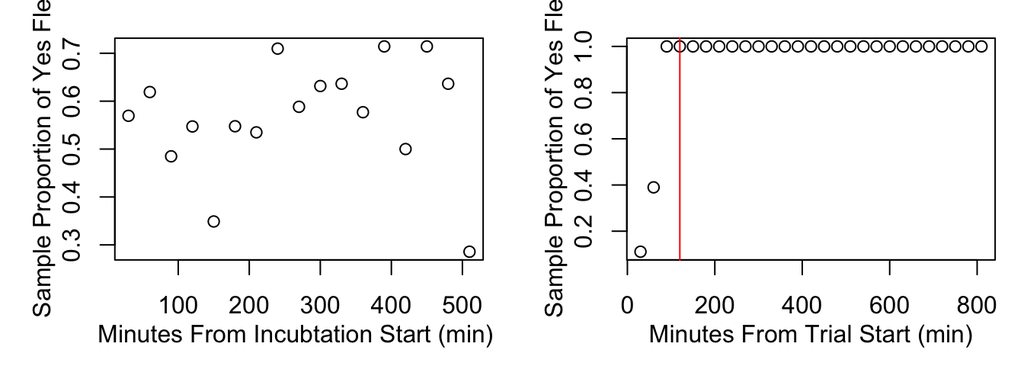

```r
# Plotting observed proportions of yes flew by minutes from incubation start
p1 <- as.grob(expression(plot(sample_prop ~ min_from_IncStart, data=cat_data1,
     ylab="Sample Proportion of Yes Flew", xlab="Minutes From Incubtation Start (min) ",
     main="Observed proportions of yes flew by minutes from incubation start")
))

# Plotting observed proportions of yes flew by minutes from trial start
p2 <- as.grob(expression(
  plot(sample_prop ~ minute_duration, data=cat_data2,
     ylab="Sample Proportion of Yes Flew", xlab="Minutes From Trial Start (min)",
     main="Observed proportions of yes flew by minutes from trial start") %>%
  abline(v=120, col="red")
))

grid.arrange(p1,p2, ncol=2)
```

### Testing Start Time

How did/does the time of day in which a bug was tested impact how long the bug flew for/whether the bug flew or not? When all bugs were considered, the effect of start time was marginal. When only bugs that flew were considered, the effect of start time was significant. From this we see that time was a limitation on our experimental set-up.

```r
par(mfrow=c(1,2))

### Plot trial duration (min) vs. time_start | all bugs
x = chron(times = data_tested$time_start)
y = data_tested$recording_duration / (60*60)

fit <- lm(y~x, data=data_tested)
summary(fit)
```

```
##
## Call:
## lm(formula = y ~ x, data = data_tested)
##
## Residuals:
##     Min      1Q  Median      3Q     Max
## -1.8061 -1.4060 -1.1175 -0.5736 11.2788
##
## Coefficients:
##             Estimate Std. Error t value Pr(>|t|)
## (Intercept)   2.9330     0.5573   5.263 1.97e-07 ***
## x            -2.2654     1.1912  -1.902   0.0577 .
## ---
## Signif. codes:  0 '***' 0.001 '**' 0.01 '*' 0.05 '.' 0.1 ' ' 1
##
## Residual standard error: 2.89 on 612 degrees of freedom
## Multiple R-squared:  0.005875,   Adjusted R-squared:  0.004251
## F-statistic: 3.617 on 1 and 612 DF,  p-value: 0.05767
```

```r
cf <- round(coef(fit), 2)
eq <- paste0("portion_flew = ", cf[1],
             ifelse(sign(cf[2])==1, " + ", " - "), abs(cf[2]), "*time_start ")
plot(x,y, xlab= "Starting Time", ylab="Duration (hr)")
abline(coef(fit)[1:2], col="blue")

### Plot trial duration (min) vs. time_start | bugs that flew only
all_flew <- filter(data_all, flew_b == 1)
x = chron(times = all_flew$time_start)
y = all_flew$recording_duration / (60*60)

fit <- lm(y~x, data=all_flew)
summary(fit)
```

```
##
## Call:
## lm(formula = y ~ x, data = all_flew)
##
## Residuals:
##     Min      1Q  Median      3Q     Max
## -2.8203 -2.3285 -1.6447  0.4281 10.0744
##
## Coefficients:
##             Estimate Std. Error t value Pr(>|t|)
## (Intercept)   4.8432     0.9162   5.286 2.23e-07 ***
## x            -4.2197     1.9521  -2.162   0.0313 *
## ---
## Signif. codes:  0 '***' 0.001 '**' 0.01 '*' 0.05 '.' 0.1 ' ' 1
##
## Residual standard error: 3.547 on 341 degrees of freedom
## Multiple R-squared:  0.01352,    Adjusted R-squared:  0.01062
## F-statistic: 4.672 on 1 and 341 DF,  p-value: 0.03135
```

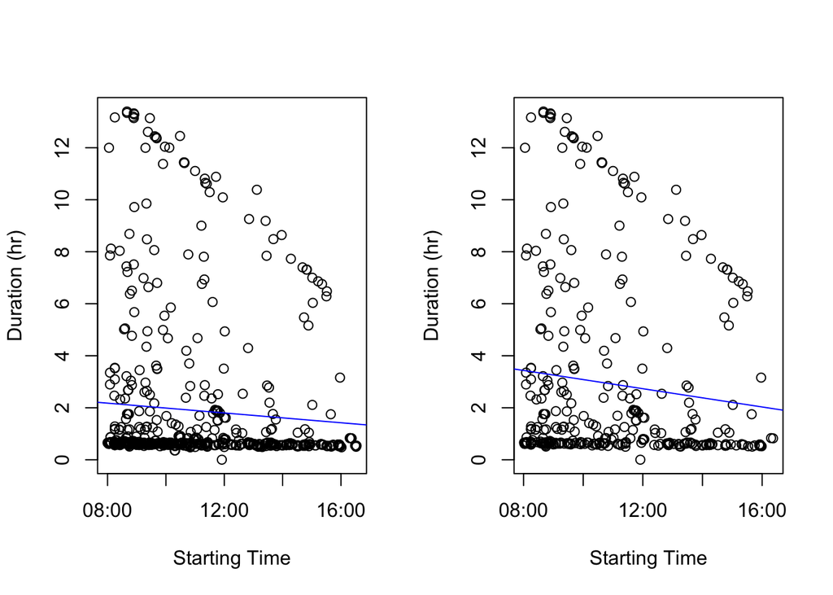

```r
cf <- round(coef(fit), 2)
eq <- paste0("portion_flew = ", cf[1],
             ifelse(sign(cf[2])==1, " + ", " - "), abs(cf[2]), "*time_start ")
plot(x,y, xlab= "Starting Time", ylab="Duration (hr)")
abline(coef(fit)[1:2], col="blue")
```

[figure not shown]

```r
c1=1.4
c2=1.2
c3=1.2

data_flew = data_tested %>%
  filter(flew_b==1)
d = data_flew
data_flew$start_time = chron(times = data_flew$time_start)
data_flew$recording_dur_hr = data_flew$recording_duration / (60*60)

x=data_flew$start_time
y=data_flew$recording_dur_hr

m <- lm(recording_dur_hr ~ start_time, data=data_flew)
x.seq = seq(min(x) - sd(x), max(x) + sd(x), length.out=100)
m <- lm(y ~ x, data=data_flew)
prd <- data.frame(x=x.seq) # newdata
err <- predict(m, newdata = prd, se.fit = TRUE)
prd$lci <- err$fit - 1.96 * err$se.fit
prd$fit <- err$fit
prd$uci <- err$fit + 1.96 * err$se.fit
mu_ci <- t(matrix(c(prd$lci,prd$uci), ncol=2))

colfunc <- colorRampPalette(c("red", "orange"))
plot(data_flew$recording_dur_hr ~ data_flew$start_time,
     pch=16,
     xlab = "Trial Start Time (HR:MIN)",
     ylab= "Recording Duration (HR)",
     cex=c2,
     cex.lab=c3,
     cex.axis=c2,
     ylim=c(0,14),
     #col = alpha("black", 0.7),
     #bty="n"
     )
abline(m, lty=2)
shade(mu_ci, lim = prd$x)
pval <- paste0("p = ", round(summary(m)$coefficients[8],3), "*")
text(chron(times = "14:15:15"), 4, pval, cex=c3)
```

```r
#title("Time of Day Tested", adj = 0.05, line = 0, cex.main=c1)
#title("(a)", adj = 0.05, line = 0, cex.main=1.4)

summary(lm(recording_dur_hr ~ start_time, data=data_flew))
```

```
##
## Call:
## lm(formula = recording_dur_hr ~ start_time, data = data_flew)
##
## Residuals:
##     Min      1Q  Median      3Q     Max
## -2.8203 -2.3285 -1.6447  0.4281 10.0744
##
## Coefficients:
##             Estimate Std. Error t value Pr(>|t|)
## (Intercept)   4.8432     0.9162   5.286 2.23e-07 ***
## start_time   -4.2197     1.9521  -2.162   0.0313 *
## ---
## Signif. codes:  0 '***' 0.001 '**' 0.01 '*' 0.05 '.' 0.1 ' ' 1
##
## Residual standard error: 3.547 on 341 degrees of freedom
## Multiple R-squared:  0.01352,    Adjusted R-squared:  0.01062
## F-statistic: 4.672 on 1 and 341 DF,  p-value: 0.03135
```

### Days from Experiment Start

```r
cat_data_days <- categorize_data(data_tested, all_of("days_from_start"), all_of("flew_b"), 1, 0, 1)
```

```
## days_from_start 1    Cases: 37   Sample Proportion: 0.7027027
## days_from_start 2    Cases: 21   Sample Proportion: 0.7142857
## days_from_start 3    Cases: 35   Sample Proportion: 0.6857143
## days_from_start 4    Cases: 31   Sample Proportion: 0.5483871
## days_from_start 5    Cases: 22   Sample Proportion: 0.5
## days_from_start 8    Cases: 43   Sample Proportion: 0.4883721
## days_from_start 9    Cases: 41   Sample Proportion: 0.5365854
## days_from_start 10   Cases: 41   Sample Proportion: 0.7073171
## days_from_start 11   Cases: 30   Sample Proportion: 0.5666667
## days_from_start 12   Cases: 33   Sample Proportion: 0.6060606
## days_from_start 16   Cases: 47   Sample Proportion: 0.5106383
## days_from_start 17   Cases: 52   Sample Proportion: 0.5961538
## days_from_start 18   Cases: 52   Sample Proportion: 0.4807692
## days_from_start 19   Cases: 28   Sample Proportion: 0.6071429
## days_from_start 22   Cases: 63   Sample Proportion: 0.3968254
```

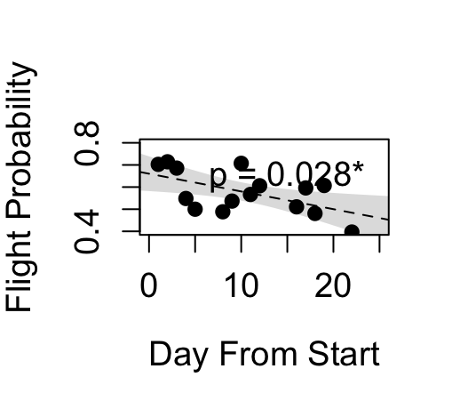

```r
x=cat_data_days$days_from_start
y=cat_data_days$sample_prop

m <- lm(sample_prop ~ days_from_start, data=cat_data_days)
x.seq = seq(min(x) - sd(x), max(x) + sd(x), length.out=100)
m <- lm(y ~ x, data=cat_data_days)
prd <- data.frame(x=x.seq) # newdata
err <- predict(m, newdata = prd, se.fit = TRUE)
prd$lci <- err$fit - 1.96 * err$se.fit
prd$fit <- err$fit
prd$uci <- err$fit + 1.96 * err$se.fit
mu_ci <- t(matrix(c(prd$lci,prd$uci), ncol=2))

colfunc <- colorRampPalette(c("red", "orange"))
plot(cat_data_days$sample_prop ~ cat_data_days$days_from_start,
     pch=16,
     xlab = "Day From Start",
     ylab= "Flight Probability",
     cex=c2,
     cex.lab=c3,
     cex.axis=c2,
     xlim=c(0,25),
     ylim=c(0.4, 0.8),
     #col = alpha("black", 0.7),
     #bty="n"
     )
abline(m, lty=2)
shade(mu_ci, lim = prd$x)
pval <- paste0("p = ", round(summary(m)$coefficients[8],3), "*")
text(15, 0.65, pval, cex=c3)
```

```r
#title("Age", adj = 0.05, line = 0, cex.main=c1)
#title("(a)", adj = 0.05, line = 0, cex.main=1.4)

summary(glm(flew_b ~ days_from_start_c, data=data_tested, family="binomial"))
```

```
##
## Call:
## glm(formula = flew_b ~ days_from_start_c, family = "binomial",
##     data = data_tested)
##
## Deviance Residuals:
##    Min      1Q  Median      3Q     Max
## -1.460  -1.226   0.932   1.071   1.235
##
## Coefficients:
##                   Estimate Std. Error z value Pr(>|z|)
## (Intercept)        0.23928    0.08192   2.921  0.00349 **
## days_from_start_c -0.03545    0.01184  -2.995  0.00274 **
## ---
## Signif. codes:  0 '***' 0.001 '**' 0.01 '*' 0.05 '.' 0.1 ' ' 1
##
## (Dispersion parameter for binomial family taken to be 1)
##
##     Null deviance: 842.72  on 613  degrees of freedom
## Residual deviance: 833.62  on 612  degrees of freedom
## AIC: 837.62
##
## Number of Fisher Scoring iterations: 4
```

```r
summary(lm(sample_prop ~ days_from_start, data=cat_data_days))
```

```
##
## Call:
## lm(formula = sample_prop ~ days_from_start, data = cat_data_days)
##
## Residuals:
##       Min        1Q    Median        3Q       Max
## -0.120275 -0.065780 -0.005571  0.060198  0.127073
##
## Coefficients:
##                  Estimate Std. Error t value Pr(>|t|)
## (Intercept)      0.660306   0.040058  16.484 4.29e-10 ***
## days_from_start -0.008006   0.003250  -2.464   0.0285 *
## ---
## Signif. codes:  0 '***' 0.001 '**' 0.01 '*' 0.05 '.' 0.1 ' ' 1
##
## Residual standard error: 0.08194 on 13 degrees of freedom
## Multiple R-squared:  0.3183, Adjusted R-squared:  0.2658
## F-statistic: 6.069 on 1 and 13 DF,  p-value: 0.02848
```

## Biological Features

### Host, Sex, Distance From Sympatric Zone

```r
summary <-aggregate(flew_b~sex*host_plant*sym_dist, data=data_all, FUN=mean)
summary
```

```
##    sex  host_plant  sym_dist     flew_b
## 1    F  K. elegans 0.0000000 0.33333333
## 2    M  K. elegans 0.0000000 0.30555556
## 3    F C. corindum 0.2046150 0.44444444
## 4    M C. corindum 0.2046150 0.50000000
## 5    F C. corindum 0.2047546 0.00000000
## 6    M C. corindum 0.2047546 0.00000000
## 7    F C. corindum 0.2178735 0.29629630
## 8    M C. corindum 0.2178735 0.76470588
## 9    F C. corindum 0.2178735 0.00000000
## 10   M C. corindum 0.2178735 0.00000000
## 11   F C. corindum 0.2348005 0.10000000
## 12   M C. corindum 0.2348005 0.95000000
## 13   F C. corindum 0.2638382 0.18181818
## 14   M C. corindum 0.2638382 0.52173913
```

[output cut: 26 more lines]

[figure not shown]

```r
par(mar=c(6.5, 5.5, 5.5, 9.5), xpd=TRUE)
plot(summary$flew_b~summary$sym_dist,
     col=c(1,2)[as.factor(summary$sex)], # Female = Black, Male = Red
     pch=c(19,22)[as.factor(summary$host_plant)], # K. elegans = Squares C.corindum = circles
     main="Observed Data",
     xlab = "Distance from Sympatric Zone (°)",
     ylab= "Proportion Flew")
legend("topright",
       legend = c("C. corindum and F", "C. corindum and M", "K. elegans and F" , "K. elegans and M"),
       inset=c(-0.23,0.2),
       col=c(1,2),
       pch = c(19,19, 22,22),
       title="Groups")
```

### Host, Sex, Distance From Sympatric Zone, Mass

```r
data_mass <- data_all %>%
  filter(!is.na(mass))

cat_data5 <- categorize_data_MF(data_mass, all_of("mass"), all_of("sex_c"),
                                all_of("host_c"), all_of("flew_b"), 0.010, 0.015, 0.025)
```

```
## Mass 0.035   Sex: M  Host Plant: 1   Cases: 2    Sample Proportion: 0
## Mass 0.045   Sex: M  Host Plant: -1  Cases: 2    Sample Proportion: 0.5
## Mass 0.055   Sex: F  Host Plant: 1   Cases: 8    Sample Proportion: 0.25
## Mass 0.055   Sex: M  Host Plant: 1   Cases: 11   Sample Proportion: 0.3636364
## Mass 0.055   Sex: F  Host Plant: -1  Cases: 22   Sample Proportion: 0.4545455
## Mass 0.055   Sex: M  Host Plant: -1  Cases: 51   Sample Proportion: 0.6666667
## Mass 0.065   Sex: F  Host Plant: 1   Cases: 10   Sample Proportion: 0.5
## Mass 0.065   Sex: M  Host Plant: 1   Cases: 1    Sample Proportion: 0
## Mass 0.065   Sex: F  Host Plant: -1  Cases: 20   Sample Proportion: 0.4
## Mass 0.065   Sex: M  Host Plant: -1  Cases: 10   Sample Proportion: 0.5
## Mass 0.075   Sex: F  Host Plant: 1   Cases: 12   Sample Proportion: 0.5833333
## Mass 0.085   Sex: F  Host Plant: -1  Cases: 23   Sample Proportion: 0.4782609
## Mass 0.105   Sex: F  Host Plant: 1   Cases: 1    Sample Proportion: 1
## Mass 0.115   Sex: F  Host Plant: -1  Cases: 19   Sample Proportion: 0.1578947
## Mass 0.135   Sex: F  Host Plant: 1   Cases: 1    Sample Proportion: 1
## Mass 0.145   Sex: F  Host Plant: -1  Cases: 5    Sample Proportion: 0
## Mass 0.205   Sex: F  Host Plant: -1  Cases: 1    Sample Proportion: 0
```

[figure not shown]

```r
par(mar=c(6.5, 5.5, 5.5, 9.5), xpd=TRUE)
plot(cat_data5$sample_prop~cat_data5$mass,
     col=c(1,2)[as.factor(cat_data5$sex_c)], # Female = Black, Male = Red
     pch=c(19,22)[as.factor(cat_data5$host_c)], # K. elegans = Squares, C.corindum = circles
     main="Observed Data",
     xlab = "Mass (g)",
     ylab= "Proportion Flew")
legend("topright",
       legend = c("C. corindum and F", "C. corindum and M", "K. elegans and F" , "K. elegans and M"),
       inset=c(-0.23,0.2),
       col=c(1,2),
       pch = c(19,19, 22,22),
       title="Groups")
```

### Mass

```r
# Plot All
data_mass <- data_all %>%
  filter(!is.na(mass))

cat_data3 <- categorize_data(data_mass, all_of("mass"), all_of("flew_b"),  0.010, 0.015, 0.025)
```

```
## mass 0.025   Cases: 4    Sample Proportion: 0.25
## mass 0.035   Cases: 123  Sample Proportion: 0.6747967
## mass 0.045   Cases: 206  Sample Proportion: 0.7281553
## mass 0.055   Cases: 92   Sample Proportion: 0.5434783
## mass 0.065   Cases: 41   Sample Proportion: 0.4390244
## mass 0.075   Cases: 35   Sample Proportion: 0.5142857
## mass 0.085   Cases: 31   Sample Proportion: 0.1935484
## mass 0.095   Cases: 28   Sample Proportion: 0.2142857
## mass 0.105   Cases: 20   Sample Proportion: 0.2
## mass 0.115   Cases: 13   Sample Proportion: 0.3076923
## mass 0.125   Cases: 7    Sample Proportion: 0
## mass 0.135   Cases: 6    Sample Proportion: 0.1666667
## mass 0.145   Cases: 3    Sample Proportion: 0.3333333
## mass 0.155   Cases: 1    Sample Proportion: 0
## mass 0.185   Cases: 1    Sample Proportion: 0
```

```r
# Plot Trial 1
data_T1 <-data_all[data_all$trial_type=="T1",]
data_mass_T1 <- data_T1 %>%
  filter(!is.na(mass))

cat_data4 <- categorize_data(data_mass_T1, all_of("mass"), all_of("flew_b"),  0.010, 0.015, 0.025)
```

```
## mass 0.025   Cases: 4    Sample Proportion: 0.25
## mass 0.035   Cases: 79   Sample Proportion: 0.7468354
## mass 0.045   Cases: 104  Sample Proportion: 0.7596154
## mass 0.055   Cases: 52   Sample Proportion: 0.5384615
## mass 0.065   Cases: 21   Sample Proportion: 0.5238095
## mass 0.075   Cases: 19   Sample Proportion: 0.5789474
## mass 0.085   Cases: 12   Sample Proportion: 0.25
## mass 0.095   Cases: 11   Sample Proportion: 0.1818182
## mass 0.105   Cases: 9    Sample Proportion: 0.2222222
## mass 0.115   Cases: 8    Sample Proportion: 0.375
## mass 0.125   Cases: 4    Sample Proportion: 0
## mass 0.135   Cases: 4    Sample Proportion: 0.25
## mass 0.155   Cases: 1    Sample Proportion: 0
## mass 0.185   Cases: 1    Sample Proportion: 0
```

```r
# Plot Trial 2
data_T2 <-data_all[data_all$trial_type=="T2",]
data_mass_T2 <- data_T2 %>%
  filter(!is.na(mass))

cat_data5 <- categorize_data(data_mass_T2, all_of("mass"), all_of("flew_b"),  0.010, 0.015, 0.025)
```

```
## mass 0.035   Cases: 44   Sample Proportion: 0.5454545
## mass 0.045   Cases: 102  Sample Proportion: 0.6960784
## mass 0.055   Cases: 40   Sample Proportion: 0.55
## mass 0.065   Cases: 20   Sample Proportion: 0.35
## mass 0.075   Cases: 16   Sample Proportion: 0.4375
## mass 0.085   Cases: 19   Sample Proportion: 0.1578947
## mass 0.095   Cases: 17   Sample Proportion: 0.2352941
## mass 0.105   Cases: 11   Sample Proportion: 0.1818182
## mass 0.115   Cases: 5    Sample Proportion: 0.2
## mass 0.125   Cases: 3    Sample Proportion: 0
## mass 0.135   Cases: 2    Sample Proportion: 0
## mass 0.145   Cases: 3    Sample Proportion: 0.3333333
```

[figure not shown]

```r
par(mfrow=c(1,2))

# Plot Trial 1
fit<-lm(flew_b~mass, data=data_T1)
coeff <- coefficients(summary(fit))

mass_seq <- seq(from=0.0, to=0.18, length.out=30)
mu <- link(fit, data=data.frame(mass=mass_seq))
mu.PI <- apply(mu,2,PI, prob=0.89)

eq <- paste0("prop flew = ", round(coeff[1],2),
             ifelse(sign(coeff[2])==1, " + ", " - "),
             abs(round(coeff[2],2)), "*mass")

plot(as.matrix(cat_data4[1]),
     as.matrix(cat_data4[3]),
     ylab="Sample Proportion of Yes Flew",
     xlab="Mass (g)",
     main="Trial 1", pch=16)
shade(mu.PI, mass_seq)
abline(coeff[1], coeff[2], lty=2)
text(0.13, 0.68, eq)

# Plot Trial 2
fit<-lm(flew_b~mass, data=data_T2)
coeff <- coefficients(summary(fit))

mass_seq <- seq(from=0.0, to=0.18, length.out=30)
mu <- link(fit, data=data.frame(mass=mass_seq))
mu.PI <- apply(mu,2,PI, prob=0.89)

eq <- paste0("prop flew = ", round(coeff[1],2),
             ifelse(sign(coeff[2])==1, " + ", " - "),
             abs(round(coeff[2],2)), "*mass")

plot(as.matrix(cat_data5[1]),
     as.matrix(cat_data5[3]),
     ylab="Sample Proportion of Yes Flew",
     xlab="Mass (g)",
     main="Trial 2", pch=16)
shade(mu.PI, mass_seq)
abline(coeff[1], coeff[2], lty=2)
text(0.105, 0.6, eq)
```

## Females

```r
data_fem <- data_all[data_all$sex=="F",]
```

## Mass, Eggs

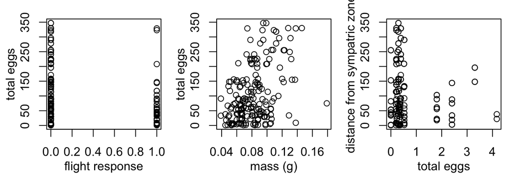

```r
pf1 <- as.grob(expression(
  plot(data_fem$flew_b, data_fem$total_eggs, xlab="flight response", ylab="total eggs")))
# seems like if you generally laid less eggs you flew, but a lot of females laid few and also didn't fly
pf2 <- as.grob(expression(
  plot(data_fem$mass, data_fem$total_eggs, xlab="mass (g)", ylab="total eggs")))
pf3 <- as.grob(expression(
  plot(data_fem$sym_dist,data_fem$total_eggs, xlab="total eggs", ylab="distance from sympatric zone")))
grid.arrange(pf1,pf2,pf3, ncol=3)
```

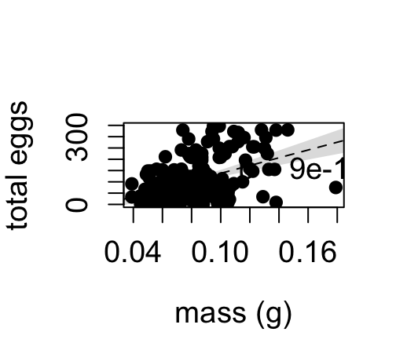

```r
# remove missing mass
data_fem_temp = data_fem %>%
  filter(!is.na(mass))

x=data_fem_temp$mass
y=data_fem_temp$total_eggs

m <- lm(total_eggs ~ mass, data=data_fem_temp)
x.seq = seq(min(x) - sd(x), max(x) + sd(x), length.out=100)
m <- lm(y ~ x, data=data_fem_temp)
prd <- data.frame(x=x.seq) # newdata
err <- predict(m, newdata = prd, se.fit = TRUE)
prd$lci <- err$fit - 1.96 * err$se.fit
prd$fit <- err$fit
prd$uci <- err$fit + 1.96 * err$se.fit
mu_ci <- t(matrix(c(prd$lci,prd$uci), ncol=2))

colfunc <- colorRampPalette(c("red", "orange"))
plot(data_fem_temp$total_eggs ~ data_fem_temp$mass,
     pch=16,
     xlab = "mass (g)",
     ylab= "total eggs",
     cex=c2,
     cex.lab=c3,
     cex.axis=c2,
     #ylim=c(0,14),
     #col = alpha("black", 0.7),
     #bty="n"
     )
abline(m, lty=2)
shade(mu_ci, lim = prd$x)
pval <- paste0("p = ", round(summary(m)$coefficients[8],10), "*")
text(0.16, 150, pval, cex=c3)
```

```r
#title("Time of Day Tested", adj = 0.05, line = 0, cex.main=c1)
#title("(a)", adj = 0.05, line = 0, cex.main=1.4)

summary(lm(total_eggs ~ mass, data=data_fem_temp))
```

```
##
## Call:
## lm(formula = total_eggs ~ mass, data = data_fem_temp)
##
## Residuals:
##     Min      1Q  Median      3Q     Max
## -198.66  -61.16  -14.70   61.67  236.08
##
## Coefficients:
##             Estimate Std. Error t value Pr(>|t|)
## (Intercept)   -34.45      22.75  -1.515    0.132
## mass         1721.31     266.48   6.459 9.02e-10 ***
## ---
## Signif. codes:  0 '***' 0.001 '**' 0.01 '*' 0.05 '.' 0.1 ' ' 1
##
## Residual standard error: 85.47 on 185 degrees of freedom
##   (26 observations deleted due to missingness)
## Multiple R-squared:  0.184,  Adjusted R-squared:  0.1796
## F-statistic: 41.72 on 1 and 185 DF,  p-value: 9.022e-10
```

```r
path = paste0(source_path, "delta-females.R")
source(path)
```

```
##     ID flew_delta mass_diff flew_count egg_diff
## 21  53          0    -0.039          2       -1
## 34 214          0    -0.038          2        1
## 17 319          0    -0.034          2        1
## 32 101          0    -0.026          0        1
## 14 155          0    -0.026          0       -1
## 26 407          0    -0.020          0       -1
## 7  147          0    -0.014          2        1
## 11 151          0    -0.014          2        1
## 5  130         -1    -0.008          1        1
## 13 132          0    -0.006          0        1
## 2   37          0    -0.004          0        1
## 8  109          0    -0.002          0        1
## 20 233          0    -0.002          0       -1
## 28 438          0     0.003          2        1
```

[output cut: 20 more lines]

Three things noticed:

1. 12 of the 34 rows flew twice (in both trials).
2. 12 of the 34 did not flew at all (in either trial).
3. there were no cases in which the flight diff = 1, so no female bugs flew in T2 but not T1. But 10 cases of the 34 that flew in T1 but not T2.

```r
cat_data10 <- categorize_data_MF2(egg_data_final, "mass_diff", "flew_count", "flew_delta", 0.005, 0.010, -0.040)
```

```
## Mass -0.03   Flight Count: 2     Cases: 3    Sample Proportion: 0
## Mass -0.02   Flight Count: 0     Cases: 2    Sample Proportion: 0
## Mass -0.01   Flight Count: 0     Cases: 1    Sample Proportion: 0
## Mass -0.01   Flight Count: 2     Cases: 2    Sample Proportion: 0
## Mass 0.00    Flight Count: 1     Cases: 5    Sample Proportion: -0.2
## Mass 0.01    Flight Count: 0     Cases: 2    Sample Proportion: 0
## Mass 0.01    Flight Count: 2     Cases: 1    Sample Proportion: 0
## Mass 0.02    Flight Count: 1     Cases: 3    Sample Proportion: -0.6666667
## Mass 0.02    Flight Count: 2     Cases: 3    Sample Proportion: 0
## Mass 0.03    Flight Count: 1     Cases: 6    Sample Proportion: -1
## Mass 0.04    Flight Count: 0     Cases: 2    Sample Proportion: -0.5
## Mass 0.05    Flight Count: 2     Cases: 2    Sample Proportion: 0
## Mass 0.06    Flight Count: 2     Cases: 1    Sample Proportion: 0
## Mass 0.07    Flight Count: 1     Cases: 1    Sample Proportion: -1
```

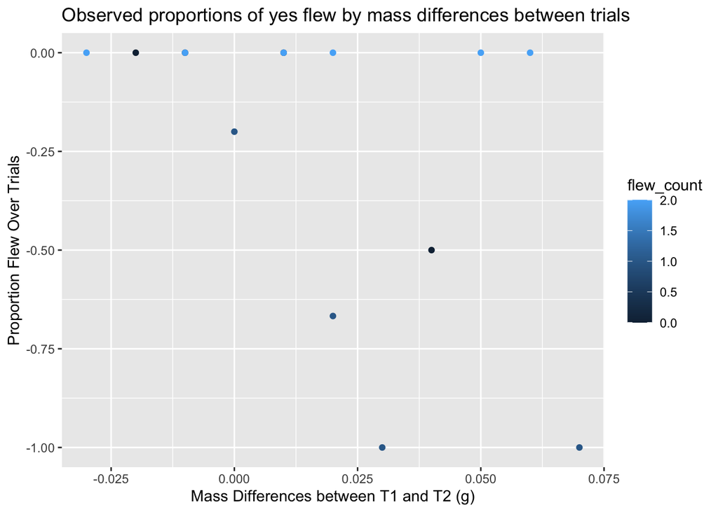

```r
gf_point(sample_prop ~ mass_diff, data=cat_data10, col=~flew_count,
         xlab = "Mass Differences between T1 and T2 (g)", ylab= "Proportion Flew Over Trials",
         title= "Observed proportions of yes flew by mass differences between trials")
```

```r
fit <- lm(sample_prop~mass_diff, data=cat_data10)
coeff <- coefficients(summary(fit))

eq <- paste0("prop_flew = ", round(coeff[1],3),
             ifelse(sign(coeff[2])==1, " + ", " - "),
             abs(round(coeff[2],3)), "*mass_diff")

mass_diff.seq <- seq(from=-0.04, to=0.08, length.out=30)
mu <- link(fit, data=data.frame(mass_diff=mass_diff.seq)) # gives warning
```

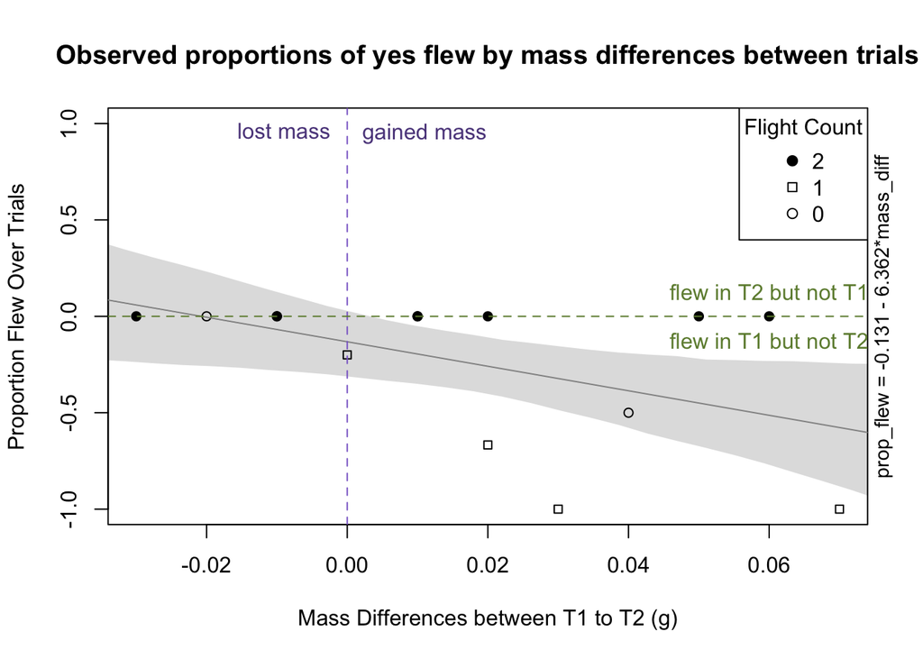

```r
mu.PI <- apply(mu,2,PI, prob=0.89) # maybe change to 95 later

plot(as.matrix(cat_data10[1]),
     as.matrix(cat_data10[3]),
     #col=c(3,2,1)[as.factor(cat_data10$flew_count)], # green = 2, black = -1
     #col=c(1,2)[as.factor(summary$sex)], # Female = Black, Male = Red
     pch=c(21,22,19)[as.factor(cat_data10$flew_count)],
     #col=c(1,2)[as.factor(cat_data11$egg_diff)], # there would be
     ylim = c(-1,1),
     ylab="Proportion Flew Over Trials",
     xlab="Mass Differences between T1 to T2 (g)",
     main="Observed proportions of yes flew by mass differences between trials",
     cex=0.9)
abline(coeff[1], coeff[2], col="darkgrey")
mtext(eq, side=4, cex=0.9)
shade(mu.PI, mass_diff.seq)
abline(v=0, col="mediumpurple3", lty=2)
text(0.011, 0.95, c("gained mass"),col="mediumpurple4")
text(-0.009, 0.963, c("lost mass"), col="mediumpurple4")
abline(h=0, col="darkolivegreen4", lty=2)
text(0.060, 0.127, c("flew in T2 but not T1"),col="darkolivegreen4")
text(0.060, -0.127, c("flew in T1 but not T2"),col="darkolivegreen4")
legend("topright",
       #legend = c("Both Trials","One Trial", "No Trial"),
       legend = c("2", "1", "0"),
       #inset=c(-0.03,0.02),
       pch = c(19,22,21),
       title="Flight Count")
```

```r
egg_data_summary
```

```
##     ID flew_delta mass_diff flew_count egg_diff
## 21  53          0    -0.039          2       -1
## 34 214          0    -0.038          2        1
## 17 319          0    -0.034          2        1
## 32 101          0    -0.026          0        1
## 14 155          0    -0.026          0       -1
## 26 407          0    -0.020          0       -1
## 7  147          0    -0.014          2        1
## 11 151          0    -0.014          2        1
## 5  130         -1    -0.008          1        1
## 13 132          0    -0.006          0        1
## 2   37          0    -0.004          0        1
## 8  109          0    -0.002          0        1
## 20 233          0    -0.002          0       -1
## 28 438          0     0.003          2        1
```

[output cut: 20 more lines]

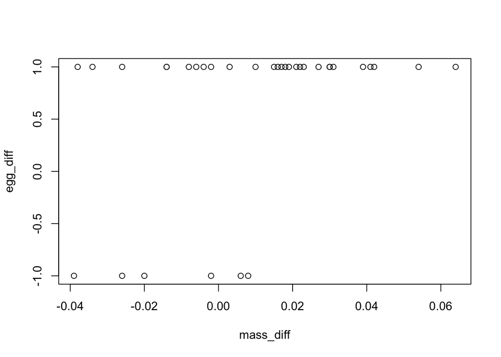

```r
plot(egg_diff ~ mass_diff, data=egg_data_summary)
```

```r
cat_data11 <- categorize_data_MF2(egg_data_final, "mass_diff", "egg_diff", "flew_delta", 0.005, 0.010, -0.040)
```

```
## Mass -0.03   Flight Count: -1    Cases: 3    Sample Proportion: 0
## Mass -0.03   Flight Count: NA    Cases: 3    Sample Proportion: 0
## Mass -0.02   Flight Count: 1     Cases: 2    Sample Proportion: 0
## Mass -0.02   Flight Count: NA    Cases: 2    Sample Proportion: 0
## Mass -0.01   Flight Count: -1    Cases: 3    Sample Proportion: 0
## Mass -0.01   Flight Count: NA    Cases: 3    Sample Proportion: 0
## Mass 0.00    Flight Count: 1     Cases: 5    Sample Proportion: -0.2
## Mass 0.00    Flight Count: NA    Cases: 5    Sample Proportion: 0
## Mass 0.01    Flight Count: 1     Cases: 3    Sample Proportion: 0
## Mass 0.01    Flight Count: NA    Cases: 3    Sample Proportion: 0
## Mass 0.02    Flight Count: 1     Cases: 6    Sample Proportion: -0.3333333
## Mass 0.02    Flight Count: NA    Cases: 6    Sample Proportion: 0
## Mass 0.03    Flight Count: 1     Cases: 6    Sample Proportion: -1
## Mass 0.03    Flight Count: NA    Cases: 6    Sample Proportion: 0
## Mass 0.04    Flight Count: 1     Cases: 2    Sample Proportion: -0.5
## Mass 0.04    Flight Count: NA    Cases: 2    Sample Proportion: 0
## Mass 0.05    Flight Count: 1     Cases: 2    Sample Proportion: 0
## Mass 0.05    Flight Count: NA    Cases: 2    Sample Proportion: 0
## Mass 0.06    Flight Count: 1     Cases: 1    Sample Proportion: 0
## Mass 0.06    Flight Count: NA    Cases: 1    Sample Proportion: 0
## Mass 0.07    Flight Count: 1     Cases: 1    Sample Proportion: -1
## Mass 0.07    Flight Count: NA    Cases: 1    Sample Proportion: 0
```

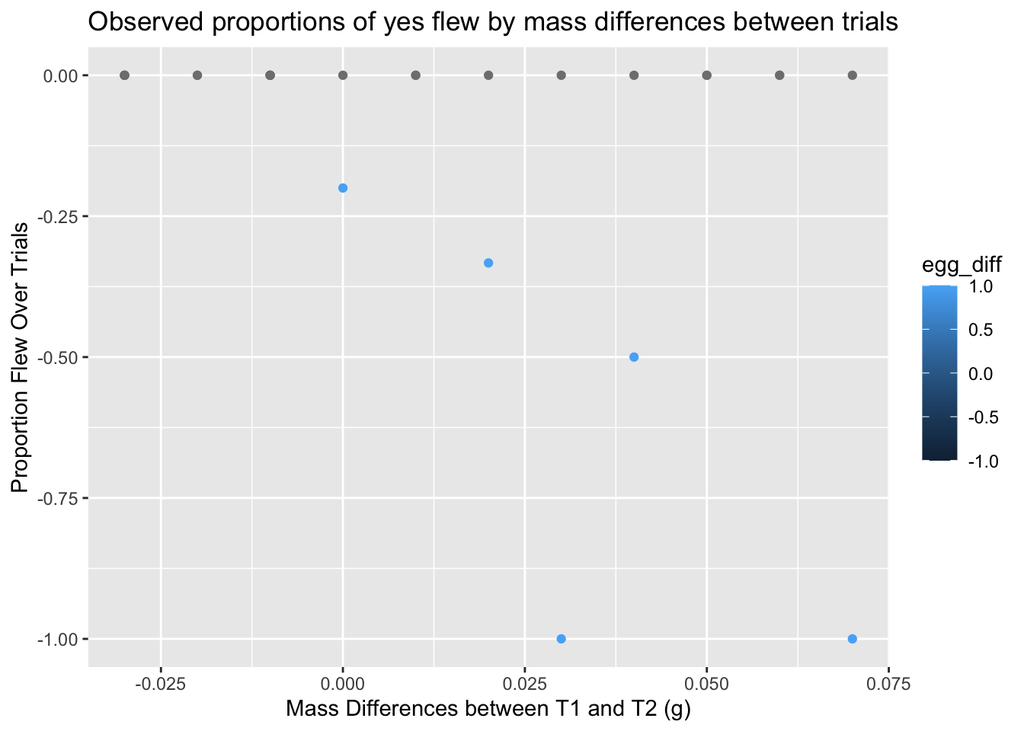

```r
gf_point(sample_prop ~ mass_diff, data=cat_data11, col=~egg_diff,
         xlab = "Mass Differences between T1 and T2 (g)", ylab= "Proportion Flew Over Trials",
         title= "Observed proportions of yes flew by mass differences between trials")
```

```r
fit <- lm(sample_prop~mass_diff, data=cat_data11)
coeff <- coefficients(summary(fit))

eq <- paste0("portion_flew = ", round(coeff[1],3),
             ifelse(sign(coeff[2])==1, " + ", " - "),
             abs(round(coeff[2],3)), "*mass_diff")

mass_diff.seq <- seq(from=-0.04, to=0.08, length.out=30)
mu <- link(fit, data=data.frame(mass_diff=mass_diff.seq)) # gives warning
```

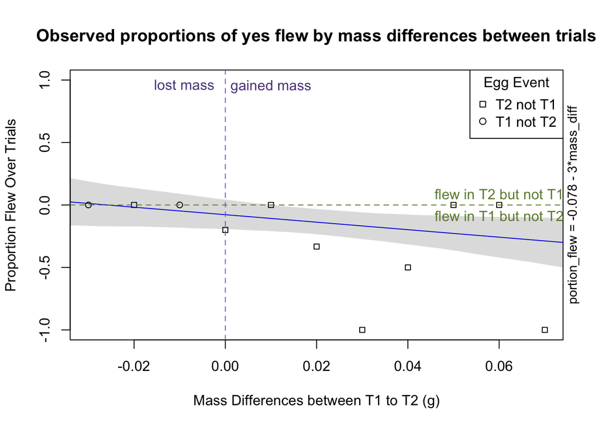

```r
mu.PI <- apply(mu,2,PI, prob=0.89) # maybe change to 95 later

plot(as.matrix(cat_data11[1]),
     as.matrix(cat_data11[3]),
     #col=c(3,2,1)[as.factor(cat_data11$flew_count)], # green = 2, black = -1
     #col=c(1,2)[as.factor(summary$sex)], # Female = Black, Male = Red
     pch=c(21,22)[as.factor(cat_data11$egg_diff)],
     ylim = c(-1,1),
     ylab="Proportion Flew Over Trials",
     xlab="Mass Differences between T1 to T2 (g)",
     main="Observed proportions of yes flew by mass differences between trials",
     cex=0.9)
abline(coeff[1], coeff[2], col="blue")
mtext(eq, side=4, cex=0.9)
shade(mu.PI, mass_diff.seq)
abline(v=0, col="mediumpurple3", lty=2)
text(0.01, 0.95, c("gained mass"),col="mediumpurple4")
text(-0.009, 0.963, c("lost mass"), col="mediumpurple4")
abline(h=0, col="darkolivegreen4", lty=2)
text(0.060, 0.087, c("flew in T2 but not T1"),col="darkolivegreen4")
text(0.060, -0.087, c("flew in T1 but not T2"),col="darkolivegreen4")
legend("topright",
       #legend = c("Both Trials","One Trial", "No Trial"),
       legend = c("T2 not T1", "T1 not T2"),
       #inset=c(-0.03,0.02),
       pch = c(22,21),
       title="Egg Event")
```

```r
fit <- lm(flew_delta~mass_diff, data=egg_data_final)
p <- paste0("p = ", round(summary(fit)[[4]][8],3), "*")

coeff <- coefficients(summary(fit))
eq <- paste0("portion_flew = ", round(coeff[1],3),
             ifelse(sign(coeff[2])==1, " + ", " - "),
             abs(round(coeff[2],3)), "*mass_diff")

mass_diff.seq <- seq(from=-0.045, to=0.07, length.out=30)
mu <- link(fit, data=data.frame(mass_diff=mass_diff.seq)) # gives warning
mu.PI <- apply(mu,2,PI, prob=0.89)
```

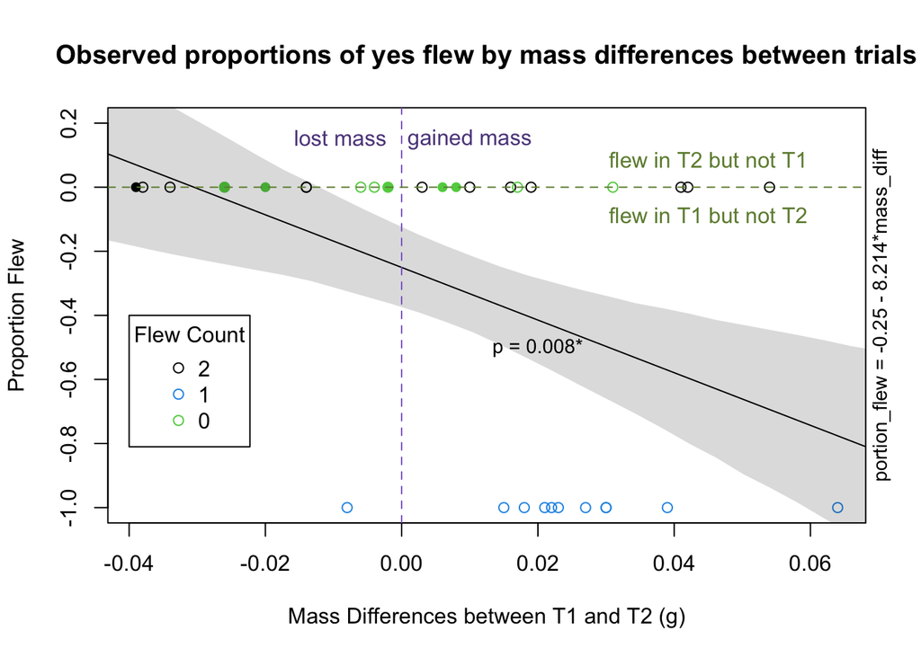

```r
summary <- aggregate(flew_delta~mass_diff*flew_count, data=egg_data_final, FUN=mean)

#par(mar=c(5.5, 9.5, 4.5, 9.5), xpd=TRUE)  # Add extra space to right of plot area; change clipping to figure
plot(egg_data_final$flew_delta~egg_data_final$mass_diff,
     col=c(3,4,1)[as.factor(egg_data_final$flew_count)], # Green = Flew 0, Blue = Flew 1, Black = Flew 2,
     main="Observed proportions of yes flew by mass differences between trials",
     xlab = "Mass Differences between T1 and T2 (g)",
     ylab= "Proportion Flew",
     ylim=c(-1,0.2),
     pch=c(16,1)[as.factor(egg_data_final$egg_diff)] # filled in means laid eggs in T1 but not T2 (not laying eggs in T2),
     )
abline(coeff[1], coeff[2], col="black")
mtext(eq, side=4, cex=0.9)
shade(mu.PI, mass_diff.seq)
abline(v=0, col="mediumpurple3", lty=2)
text(0.01, 0.15, c("gained mass"),col="mediumpurple4")
text(-0.009, 0.155, c("lost mass"), col="mediumpurple4")
abline(h=0, col="darkolivegreen4", lty=2)
text(0.045, 0.087, c("flew in T2 but not T1"),col="darkolivegreen4")
text(0.045, -0.087, c("flew in T1 but not T2"),col="darkolivegreen4")
text(0.02, -0.5, p, col= "black", cex=0.9) #pval
legend(-0.04,-0.4,
       legend = c("2", "1", "0"),
       col= c(1,4,3),
       pch = c(1),
       title="Flew Count")
```

```r
# for(r in 1:nrow(egg_data_final)){
#   delta_egg <- egg_data_final$egg_diff[r]
#   if(delta_egg < 1) {
#     lwd = 3
#     points(egg_data_final$mass_diff[r], egg_data_final$flew_delta[r], lwd=lwd, col=c(3,4,1)[as.factor(egg_data_final$flew_count[r])])
#            #pch=16,
#            #col=c(3,4,1)[as.factor(egg_data_final$flew_count[r])])
#   }
# }
```

Filled in circles mean that the bug laid eggs in T1, but not T2 so can show that really what matters more is the mass difference than the egg difference.

Now let’s do this for everyone.